# Manipulating Data in Python

## Laila A. Wahedi

### Massive Data Institute Postdoctoral Fellow McCourt School of Public Policy

### Follow along: Wahedi.us, Current Presentation

# Installing packages:

### On a Mac:

- Open terminal

### On Windows:

- Type cmd into the start menu

### What is this?

- Like an explorer window. The text at the start of the line tells you where you are.
- To see what's there, type:
  - On Mac: ls (That's an L, not an i)
  - On Windows: dir

# Installing Packages:

### Install Packages

Install some packages so they are done by the time we need them. Type:

- `pip install pandas`

When that's done, type:

- `pip install matplotlib`
- `pip install pickle`
- `pip install statsmodels`

Note: if you installed the Continuum Python distribution, you may already have some of these packages installed.

### What just happened?

- Pip is a download manager, it automatically looks online to find the package and installs it on your computer
- Similar to the CRAN Mirror
- Bonus: if you followed the link I sent to install Anaconda, you have the conda download manager too.
  - `conda install` works similarly to pip, and also works on many R packages when used with Jupyter notebooks.

# Opening Jupyter

- Open up another terminal/command prompt while your packages download
- Navigate to the directory you want your script to be in
  - Type `ls` to see what folders are in the current folder
  - Type cd .. to go one folder up
  - Type cd folder_name to go to a sub-folder
    - Type mkdir folder_name to make a folder
  - Type:
    - jupyter notebook

### What happened?

- A browser window popped up
- Address something along the lines of localhost:8888/tree
- Address is listed in the terminal/command prompt
- Go to this address from any browser to open your tree

# Your Jupyter Tree

- You should be in the folder you navigated to in terminal/cmd
- You can make folders here too
- Top right, select new notebook, python3

### Open this notebook:

- Move the file into the directory for your Jupyter Tree
- Select the file from teh Jupyter Tree
- A new tab should open in your browser.
- Add new cells to take notes as you go along.
  - Change the type of note cells to Markdown

# Some Python Basics

# What is code?

- Set of clear instructions to the computer
- Start with basic set of building blocks
- Put those building blocks together

## Goal of programming:

- Break your task into building blocks
- Put building blocks together into an **algorithm**

## Our tasks:

- Move and manipulate data using these building blocks.

# Building Blocks

[figure not shown]

- Ball and urn example

# Our First Algorithm

[figure not shown]

# Basic Data Structures

## Strings

- Text variables
- Declare with either '', or ""

```python
my_string = 'Hello World'
print(my_string)
```

```
Hello World
```

## Numbers:

- ints: integers
- floats: numbers with decimals
- Combine them to get a new float

```python
my_int = 2
my_float = 2.2
new_float = my_int+my_float
print(new_float)
type(new_float)
```

```
4.2
```

```
float
```

## Lists

- Declare with: []
- Ordered list of objects

```python
my_list = [0,1,2,3,4]
```

- Zero indexed

```python
print(my_list[1])
```

```
1
```

- Lists are Mutable:

```python
my_list[2]='hello'
print(my_list)
```

```
[0, 1, 'hello', 3, 4]
```

## Dictionaries

- key value pairs indexed by key
- Declared by {key:value}

```python
my_dictionary = {'apple':4,
                'pear':'yum'}
print(my_dictionary['apple'])
```

```
4
```

- Add key value pairs later using indexing with brackets []
- You can store data type you want

```python
my_dictionary['numbers'] = my_list
print(my_dictionary['numbers'])
```

```
[0, 1, 'hello', 3, 4]
```

## Sets

- Like a list, but:
  - Contains unique values
  - Unordered
- Declare with {}

```python
my_set = {'thing1','thing2','cat in hat','thing1', 4,4}
print(my_set)
```

```
{'thing2', 4, 'thing1', 'cat in hat'}
```

## Tuples

- Like an ordered list, but can't be changed
- Declare with ()

```python
my_tuple = (1,3,2)
print(my_tuple)
```

```
(1, 3, 2)
```

# Our First Algorithm: Strings

[figure not shown]

```python
# Declare Data
my_data = 'hello '
my_other_data = 'world'
#Manipulate it
manipulated_data = my_data+my_other_data
#Output it:
print(manipulated_data)
```

```
hello world
```

# Our First Algorithm: Numbers

[figure not shown]

```python
# Declare Data
my_data =  1
my_other_data = 5
#Manipulate it
manipulated_data = 1/5
#Output it:
print(manipulated_data)
```

```
0.2
```

# Adding Choices

[figure not shown]

# Writing Instructions Python Can Understand:

## Whitespace matters

- tabs indicate a block of code within an if statement or loop
- : marks the start of the block
- \ for a linebreak mid-line
- Line breaks allowed inside (), [], {}

# If statements

- = to assign
  - Like <- in R
- == to evaluate

```python
my_variable = 5
print(my_variable)
print(my_variable == 5)
```

```
5
True
```

- Compare values with:
  - <, <=, >, >=, ==, !=, in, not in,

```python
print(my_variable > 6)
print(my_variable in [1,4,7])
```

```
False
False
```

# Booleans and Indicators

- booleans are indicators of True or False
- In Python3, True = 1, and False = 0

```python
True + True
```

```
2
```

- None is a null value
- None evaluates to false in an if statement.

# If statements:

- Used to change behavior depending on conditionals
- Declare the statement
- Declare the conditional action within a code block, or indentation:
- Declare alternative actions in else
- Stack conditionals with elif

```python
my_bool = 'ice cream'
if my_bool == 'ice cream':
    print('yay')
elif my_bool == 'cake':
    print('woo!')
else:
    print('Woe and great tragedy!')
```

```
yay
```

## Play around yourself:

```python
check = True
# check = False
# check = None
# check = 'monkey'
# check = 0
# check = 10
print('Check is:', check)
if check == 'monkey':
    print('banana')
elif check:
    print('yes')
else:
    print('no')

if 1 not in [1,2,3]:
    print('not not in')
if 1 in [1,2,3]:
    print('in')
```

```
Check is: True
yes
in
```

# Repetition

[figure not shown]

### While loops

- Do something in block of code until condition met
- Make sure you change the condition in every loop, or it will go forever

```python
n = 0
while n < 5:
    print(n)
    n= n+1
```

```
0
1
2
3
4
```

### For loops

- repeat block of code for:
  - a certain number of iterations
  - For every element in a list
- range() gives you an iterator

```python
print('use a range:')
for i in range(3):
    print(i)
print('use a range slice:')
for i in range(3,6):
    print(i)
print('iterate throubh a list:')
for i in my_list:
    print(i)
```

```
use a range:
0
1
2
use a range slice:
3
4
5
iterate throubh a list:
0
1
hello
3
4
```

### Put them together:

- Play around on your own

```python
my_list = [0,1,'cat',None,'frog',3]
animals = []
nums = []
for i in my_list:
    if type(i)==str:
        animals.append(i)
    elif type(i)==int:
        nums.append(i)
    else:
        pass
print(animals)
print(nums)
```

```
['cat', 'frog']
[0, 1, 3]
```

# Learn More:

### These are the basic building blocks for scripting. To learn more about how to put them together to greater effect:

- Take an introductory computer science course online
- Check out GU Women Coders.
  - Can't make it in person? Their website has lots of great resources.
  - http://guwecode.georgetown.domains/

## Import packages

- Like library(package) in R
- Pandas is a dataframe data structure like dataframes in R
- matplotlib is a plotting package similar to plotting in Matlab
  - you can view plots inline in pandas notebooks with the inline command
- ggplot is a plotting package built on matplotlib like ggplot2 in R
- Pickle lets you save your workspace
- Statsmodels contains many of the statistical models you know and love

```python
import pandas as pd
import matplotlib.pyplot as plt
%matplotlib inline
# from ggplot import *
import pickle
import statsmodels.api as sm
```

# Pandas Data Frames

## Using Documentation

- Pandas website
- Stack Overflow
- Copy errors into google
- Look up syntax differences with R ## Load Data from a comma separated file
- Start by googling it: http://lmgtfy.com/?q=pandas+load+csv

## We will use the Big Allied and Dangerous Data from START

- https://dataverse.harvard.edu/file.xhtml?fileId=2298519&version=RELEASED&version=.0

```python
baad_covars = pd.read_csv('BAAD_1_Lethality_Data.tab',sep='\t')
```

# Look at the data

```python
baad_covars.head()
```

|  | mastertccode3606 | group | statespond | cowmastercountry | masterccode | fatalities19982005 | OrgAge | ordsize | terrStrong | degree | ContainRelig | ContainEthno | LeftNoReligEthno | PureRelig | PureEthno | ReligEthno | ContainRelig2 | ContainEthno2 | Islam |
| --- | --- | --- | --- | --- | --- | --- | --- | --- | --- | --- | --- | --- | --- | --- | --- | --- | --- | --- | --- |
| 0 | 50 | Animal Liberation Front (ALF) | 0 | United States of America | 2 | 0 | 30 | 0 | 0 | 1 | 0 | 0 | 0 | 0 | 0 | 0 | 0 | 0 | 0 |
| 1 | 89 | Army of God | 0 | United States of America | 2 | 1 | 24 | 0 | 0 | 0 | 1 | 0 | 0 | 1 | 0 | 0 | 1 | 0 | 0 |
| 2 | 113 | Cambodian Freedom Fighters (CFF) | 0 | United States of America | 2 | 0 | 8 | 0 | 0 | 0 | 0 | 1 | 0 | 0 | 0 | 0 | 0 | 1 | 0 |
| 3 | 126 | Coalition to Save the Preserves (CSP) | 0 | United States of America | 2 | 0 | 6 | 0 | 0 | 0 | 0 | 0 | 0 | 0 | 0 | 0 | 0 | 0 | 0 |
| 4 | 153 | Earth Liberation Front (ELF) | 0 | United States of America | 2 | 0 | 14 | 0 | 0 | 1 | 0 | 0 | 0 | 0 | 0 | 0 | 0 | 0 | 0 |

# Rename things and adjust values

```python
baad_covars.rename(columns = {'cowmastercountry':'country',
                              'masterccode':'ccode',
                       'mastertccode3606':'group_code',
                       'fatalities19982005':'fatalities'},
            inplace = True)
baad_covars.replace({'country':{'United States of America':'US'}},
            inplace = True)
print('Dimensions: ',baad_covars.shape)
baad_covars.head()
```

```
('Dimensions: ', (395, 19))
```

|  | group_code | group | statespond | country | ccode | fatalities | OrgAge | ordsize | terrStrong | degree | ContainRelig | ContainEthno | LeftNoReligEthno | PureRelig | PureEthno | ReligEthno | ContainRelig2 | ContainEthno2 | Islam |
| --- | --- | --- | --- | --- | --- | --- | --- | --- | --- | --- | --- | --- | --- | --- | --- | --- | --- | --- | --- |
| 0 | 50 | Animal Liberation Front (ALF) | 0 | US | 2 | 0 | 30 | 0 | 0 | 1 | 0 | 0 | 0 | 0 | 0 | 0 | 0 | 0 | 0 |
| 1 | 89 | Army of God | 0 | US | 2 | 1 | 24 | 0 | 0 | 0 | 1 | 0 | 0 | 1 | 0 | 0 | 1 | 0 | 0 |
| 2 | 113 | Cambodian Freedom Fighters (CFF) | 0 | US | 2 | 0 | 8 | 0 | 0 | 0 | 0 | 1 | 0 | 0 | 0 | 0 | 0 | 1 | 0 |
| 3 | 126 | Coalition to Save the Preserves (CSP) | 0 | US | 2 | 0 | 6 | 0 | 0 | 0 | 0 | 0 | 0 | 0 | 0 | 0 | 0 | 0 | 0 |
| 4 | 153 | Earth Liberation Front (ELF) | 0 | US | 2 | 0 | 14 | 0 | 0 | 1 | 0 | 0 | 0 | 0 | 0 | 0 | 0 | 0 | 0 |

# Set a useful index

```python
#Set the index
baad_covars.set_index(['group_code'],inplace = True)
baad_covars.head()
```

| group_code | group | statespond | country | ccode | fatalities | OrgAge | ordsize | terrStrong | degree | ContainRelig | ContainEthno | LeftNoReligEthno | PureRelig | PureEthno | ReligEthno | ContainRelig2 | ContainEthno2 | Islam |
| --- | --- | --- | --- | --- | --- | --- | --- | --- | --- | --- | --- | --- | --- | --- | --- | --- | --- | --- |
| 50 | Animal Liberation Front (ALF) | 0 | US | 2 | 0 | 30 | 0 | 0 | 1 | 0 | 0 | 0 | 0 | 0 | 0 | 0 | 0 | 0 |
| 89 | Army of God | 0 | US | 2 | 1 | 24 | 0 | 0 | 0 | 1 | 0 | 0 | 1 | 0 | 0 | 1 | 0 | 0 |
| 113 | Cambodian Freedom Fighters (CFF) | 0 | US | 2 | 0 | 8 | 0 | 0 | 0 | 0 | 1 | 0 | 0 | 0 | 0 | 0 | 1 | 0 |
| 126 | Coalition to Save the Preserves (CSP) | 0 | US | 2 | 0 | 6 | 0 | 0 | 0 | 0 | 0 | 0 | 0 | 0 | 0 | 0 | 0 | 0 |
| 153 | Earth Liberation Front (ELF) | 0 | US | 2 | 0 | 14 | 0 | 0 | 1 | 0 | 0 | 0 | 0 | 0 | 0 | 0 | 0 | 0 |

# Slicing

- Get specific values from the dataframe.
- Pandas has several slice operators.
  - iloc can be used to index the row by ordered integer. i.e. first row is 0, second row is 1, etc. Use this option sparingly. Better practice to use the index you have created.
  - loc uses the named index and columns.
- Index using [row, columns]
- For multiple columns, put your column names in a list
- Use : for all values
- Notice that the output keeps the index names.

```python
baad_covars.loc[:, 'fatalities'].head()
```

```
group_code
50     0
89     1
113    0
126    0
153    0
Name: fatalities, dtype: int64
```

# Look at the data

```
OrgAge    11.270886
dtype: float64
```

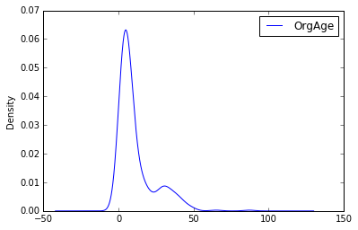

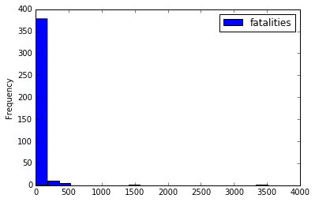

```python
baad_covars.loc[:,['OrgAge']].plot.density()
print(baad_covars.loc[:,['OrgAge']].mean())
baad_covars.loc[:,['fatalities']].plot.hist(bins=20)
```

# Slicing Using Conditionals

- Put conditionals in parentheses
- Stack multiple conditionals using:
  - & when both conditions must always apply
  - | when at least one condition must apply

```python
baad_covars.loc[(baad_covars.fatalities>1) | (baad_covars.degree>=1),
               ['group','country']].head()
```

| group_code | group | country |
| --- | --- | --- |
| 50 | Animal Liberation Front (ALF) | US |
| 153 | Earth Liberation Front (ELF) | US |
| 30035 | Maras Salvatruchas | US |
| 10042 | Group of Guerilla Combatants of Jose Maria Mor... | Mexico |
| 246 | Justice Army of the Defenseless People | Mexico |

# Handling Missing Values

### First lets make some:

```python
baad_covars.loc[(baad_covars.fatalities>1) | (baad_covars.degree>=1),
               ['terrStrong']] = None
baad_covars.loc[(baad_covars.fatalities>1) | (baad_covars.degree>=1),
               ['terrStrong']].head()
```

| group_code | terrStrong |
| --- | --- |
| 50 | NaN |
| 153 | NaN |
| 30035 | NaN |
| 10042 | NaN |
| 246 | NaN |

# Handling Missing Values

### We could index by them

```python
baad_covars.loc[baad_covars.terrStrong.isnull(),'terrStrong'].head()
```

```
group_code
50      NaN
153     NaN
30035   NaN
10042   NaN
246     NaN
Name: terrStrong, dtype: float64
```

# Handling Missing Values

### We could fill them:

```python
baad_covars['terrStrong'] = baad_covars.terrStrong.fillna(-77)
baad_covars.terrStrong.head()
```

```
group_code
50    -77.0
89      0.0
113     0.0
126     0.0
153   -77.0
Name: terrStrong, dtype: float64
```

# Making New Columns

### Assign values to a new column based on other columns:

```python
baad_covars['big'] = 0
baad_covars.loc[(baad_covars.fatalities>1) |
                (baad_covars.degree>=1),
               'big']=1
baad_covars.big.head()
```

```
group_code
50     1
89     0
113    0
126    0
153    1
Name: big, dtype: int64
```

# Reindexing: Pop the index out without losing it

```python
baad_covars.reset_index(inplace=True)
baad_covars.head()
```

|  | group_code | group | statespond | country | ccode | fatalities | OrgAge | ordsize | terrStrong | degree | ContainRelig | ContainEthno | LeftNoReligEthno | PureRelig | PureEthno | ReligEthno | ContainRelig2 | ContainEthno2 | Islam | big |
| --- | --- | --- | --- | --- | --- | --- | --- | --- | --- | --- | --- | --- | --- | --- | --- | --- | --- | --- | --- | --- |
| 0 | 50 | Animal Liberation Front (ALF) | 0 | US | 2 | 0 | 30 | 0 | -77.0 | 1 | 0 | 0 | 0 | 0 | 0 | 0 | 0 | 0 | 0 | 1 |
| 1 | 89 | Army of God | 0 | US | 2 | 1 | 24 | 0 | 0.0 | 0 | 1 | 0 | 0 | 1 | 0 | 0 | 1 | 0 | 0 | 0 |
| 2 | 113 | Cambodian Freedom Fighters (CFF) | 0 | US | 2 | 0 | 8 | 0 | 0.0 | 0 | 0 | 1 | 0 | 0 | 0 | 0 | 0 | 1 | 0 | 0 |
| 3 | 126 | Coalition to Save the Preserves (CSP) | 0 | US | 2 | 0 | 6 | 0 | 0.0 | 0 | 0 | 0 | 0 | 0 | 0 | 0 | 0 | 0 | 0 | 0 |
| 4 | 153 | Earth Liberation Front (ELF) | 0 | US | 2 | 0 | 14 | 0 | -77.0 | 1 | 0 | 0 | 0 | 0 | 0 | 0 | 0 | 0 | 0 | 1 |

# Set a multi-index

```python
baad_covars.set_index(['group','country'],inplace = True)
baad_covars.head()
```

| group | country | group_code | statespond | ccode | fatalities | OrgAge | ordsize | terrStrong | degree | ContainRelig | ContainEthno | LeftNoReligEthno | PureRelig | PureEthno | ReligEthno | ContainRelig2 | ContainEthno2 | Islam | big |
| --- | --- | --- | --- | --- | --- | --- | --- | --- | --- | --- | --- | --- | --- | --- | --- | --- | --- | --- | --- |
| Animal Liberation Front (ALF) | US | 50 | 0 | 2 | 0 | 30 | 0 | -77.0 | 1 | 0 | 0 | 0 | 0 | 0 | 0 | 0 | 0 | 0 | 1 |
| Army of God | US | 89 | 0 | 2 | 1 | 24 | 0 | 0.0 | 0 | 1 | 0 | 0 | 1 | 0 | 0 | 1 | 0 | 0 | 0 |
| Cambodian Freedom Fighters (CFF) | US | 113 | 0 | 2 | 0 | 8 | 0 | 0.0 | 0 | 0 | 1 | 0 | 0 | 0 | 0 | 0 | 1 | 0 | 0 |
| Coalition to Save the Preserves (CSP) | US | 126 | 0 | 2 | 0 | 6 | 0 | 0.0 | 0 | 0 | 0 | 0 | 0 | 0 | 0 | 0 | 0 | 0 | 0 |
| Earth Liberation Front (ELF) | US | 153 | 0 | 2 | 0 | 14 | 0 | -77.0 | 1 | 0 | 0 | 0 | 0 | 0 | 0 | 0 | 0 | 0 | 1 |

# Using the new index, make a new dataframe

- Note the new slicing operator for multi-index

```python
indonesia_grps = baad_covars.xs('Indonesia',level = 'country',drop_level=False)
indonesia_grps = indonesia_grps.loc[indonesia_grps.fatalities>=1,['degree','ContainRelig',
                                            'ContainEthno','terrStrong',
                                            'ordsize','OrgAge']]
indonesia_grps.head()
```

| group | country | degree | ContainRelig | ContainEthno | terrStrong | ordsize | OrgAge |
| --- | --- | --- | --- | --- | --- | --- | --- |
| Free Aceh Movement (GAM) | Indonesia | 1 | 1 | 1 | -77.0 | 2 | 31 |
| Jemaah Islamiya (JI) | Indonesia | 2 | 1 | 0 | -77.0 | 1 | 13 |
| Laskar Jihad | Indonesia | 3 | 1 | 1 | -77.0 | 0 | 6 |
| South Maluku Republic (RMS) | Indonesia | 0 | 0 | 1 | -77.0 | 2 | 8 |

# Warning: Making copies

- If you set a variable as equal to an object, Python creates a reference rather than copying the whole object. More efficient, unless you really want to make a copy

```python
little_df = pd.DataFrame([1,2,3,4,5],columns = ['A'])
little_df['B']=[0,1,0,1,1]
copied_df = little_df
print('before:')
print(copied_df)
little_df.loc[little_df.A == 3,'B'] = 7
print('after')
copied_df
```

```
before:
   A  B
0  1  0
1  2  1
2  3  0
3  4  1
4  5  1
after
```

|  | A | B |
| --- | --- | --- |
| 0 | 1 | 0 |
| 1 | 2 | 1 |
| 2 | 3 | 7 |
| 3 | 4 | 1 |
| 4 | 5 | 1 |

# What happened?

- copied_df changed when little_df changed.
- Let's fix that: import "copy"

```python
import copy
little_df = pd.DataFrame([1,2,3,4,5],columns = ['A'])
little_df['B']=[0,1,0,1,1]
copied_df = little_df.copy()
print('before:')
print(copied_df)
little_df.loc[little_df.A == 3,'B'] = 7
print('after')
copied_df
```

```
before:
   A  B
0  1  0
1  2  1
2  3  0
3  4  1
4  5  1
after
```

|  | A | B |
| --- | --- | --- |
| 0 | 1 | 0 |
| 1 | 2 | 1 |
| 2 | 3 | 0 |
| 3 | 4 | 1 |
| 4 | 5 | 1 |

# Saving

- Unlike R or Stata, can't just save your workspace
- Save as a csv now that we have the data we want
- Pickle a variable to recreate it without having to reset indexes, etc.

```python
indonesia_grps.to_csv('indonesia.csv')
pickle.dump(indonesia_grps, open('indonesia.p','wb'))
indonesia_grps = pickle.load(open('indonesia.p','rb'))
```

# Next time:

- Scrape Data from the internet
- Clean the data
- Merge that data into our data
- Run a basic stats and ML model

# Until then, here's some reference code on merging your data sets

# Merging and Concatenating

- Merges automatically if shared index

```python
C = pd.DataFrame(['apple','orange','grape','pear','banana'],
                 columns = ['C'],
                 index = [2,4,3,0,1])
little_df['C'] = C
little_df
```

|  | A | B | C |
| --- | --- | --- | --- |
| 0 | 1 | 0 | pear |
| 1 | 2 | 1 | banana |
| 2 | 3 | 7 | apple |
| 3 | 4 | 1 | grape |
| 4 | 5 | 1 | orange |

### Joins

- Same as SQL, inner and outer

```python
C = pd.DataFrame(['apple','orange','grape','apple'],
                 columns = ['C'],
                 index = [2,4,3,'a'])
C['cuts']=['slices','wedges','whole','spirals']
print('C:')
print(C)
print('Inner: Intersection')
print(little_df.merge(right=C,
                how='inner',
                on=None,
                left_index = True,
                right_index =True))
print('Outer: Keep all rows')
print(little_df.merge(right=C,
                how='outer',
                on=None,
                left_index = True,
                right_index =True))

print('Left: Keep little_df')
print(little_df.merge(right=C,
                how='left',
                on=None,
                left_index = True,
                right_index =True))
print('Right: Keep C')
print(little_df.merge(right=C,
                how='right',
                on=None,
                left_index = True,
                right_index =True))

print('Outer, merging on column instead of index')
print(little_df.merge(right=C,
                how='outer',
                on='C',
                left_index = True,
                right_index =True))
```

```
C:
        C     cuts
2   apple   slices
4  orange   wedges
3   grape    whole
a   apple  spirals
Inner: Intersection
   A  B     C_x     C_y    cuts
2  3  7   apple   apple  slices
3  4  1   grape   grape   whole
4  5  1  orange  orange  wedges
Outer: Keep all rows
     A    B     C_x     C_y     cuts
0  1.0  0.0    pear     NaN      NaN
1  2.0  1.0  banana     NaN      NaN
2  3.0  7.0   apple   apple   slices
3  4.0  1.0   grape   grape    whole
4  5.0  1.0  orange  orange   wedges
a  NaN  NaN     NaN   apple  spirals
Left: Keep little_df
   A  B     C_x     C_y    cuts
0  1  0    pear     NaN     NaN
1  2  1  banana     NaN     NaN
2  3  7   apple   apple  slices
3  4  1   grape   grape   whole
4  5  1  orange  orange  wedges
Right: Keep C
     A    B     C_x     C_y     cuts
2  3.0  7.0   apple   apple   slices
4  5.0  1.0  orange  orange   wedges
3  4.0  1.0   grape   grape    whole
a  NaN  NaN     NaN   apple  spirals
Outer, merging on column instead of index
     A    B       C     cuts
0  1.0  0.0    pear      NaN
1  2.0  1.0  banana      NaN
2  3.0  7.0   apple   slices
3  4.0  1.0   grape    whole
4  5.0  1.0  orange   wedges
a  NaN  NaN   apple  spirals
```

### Concatenate

- Stack dataframes on top of one another
- Stack dataframes beside one another

```python
add_df = pd.DataFrame({'A':[6],'B':[7],'C':'peach'},index= ['p'])
little_df = pd.concat([little_df,add_df])
little_df
```

[output not shown]